# PROJECT_8_(2)

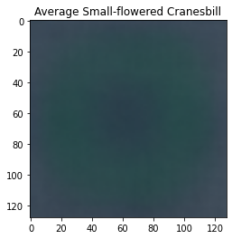

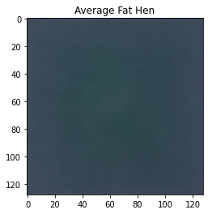

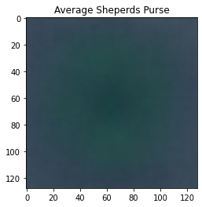

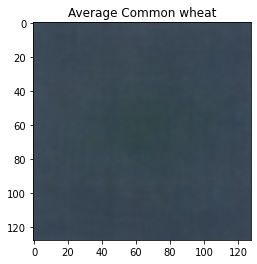

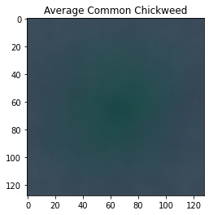

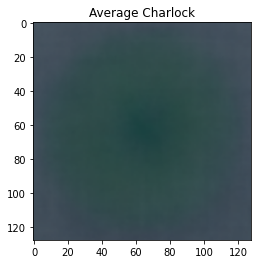

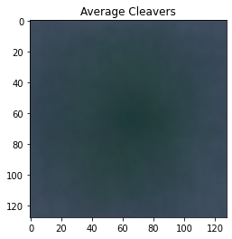

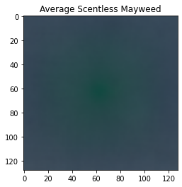

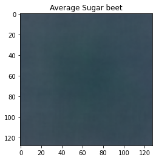

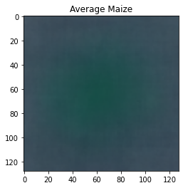

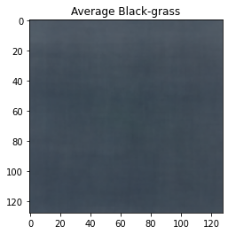

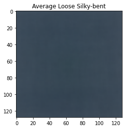

```python
#Let's plot the mean image of each plant specie in the data set
def mean_images(data, title):
  img = np.mean(data, axis = 0)
  brr=np.array(np.round(img),dtype=np.uint8)
  plt.imshow(brr, vmin=0, vmax=255, cmap='Greys_r')
  plt.title(f'Average {title}')
  plt.show()
SFC_mean = mean_images(x[0:496], 'Small-flowered Cranesbill')
FH_mean = mean_images(x[496:971], 'Fat Hen')
SP_mean = mean_images(x[971:1202], 'Sheperds Purse')
CW_mean = mean_images(x[1202:1423], 'Common wheat')
CC_mean = mean_images(x[1423:2034], 'Common Chickweed')
CH_mean = mean_images(x[2034:2424], 'Charlock')
CL_mean = mean_images(x[2424:2711], 'Cleavers')
SM_mean = mean_images(x[2711:3227], 'Scentless Mayweed')
SB_mean = mean_images(x[3227:3612], 'Sugar beet')
MZ_mean = mean_images(x[3612:3833], 'Maize')
BG_mean = mean_images(x[3833:4096], 'Black-grass')
LSB_mean = mean_images(x[4096:], 'Loose Silky-bent')
```

The mean of each plant specie above further confirms that the plant leaves which are depicted by the green shades in each picture is the differentiating factor among the plants species.

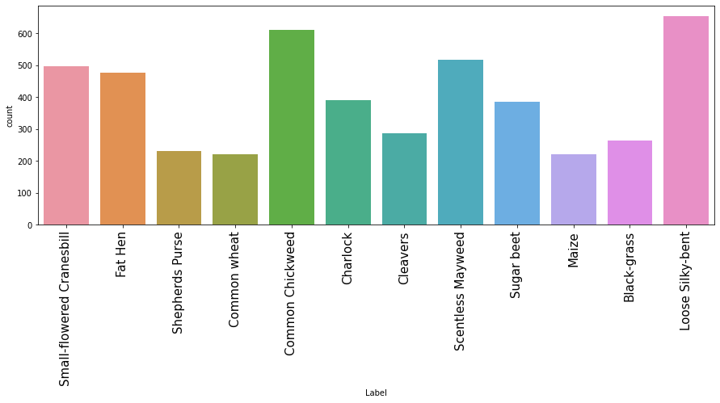

```python
#To plot the barplot of the plant labels
plt.figure(figsize=(15, 5))
plt.xticks(rotation=90, fontsize=15)
sns.countplot(y['Label'])
```

The barplot above further re-confirms Loose Silky-bent as the dorminant plant specie in the data set.

## Data Preprocessing

We shall perform the following operations on the images and print some samples before and after the preprocessing

- Guassian blurring -Convert image from RGB to HSV -Apply closing opration(one of mophological opration) -Apply segmentation -Normalisation of the images

```
# SAMPLES OF CLEANED IMAGES
```

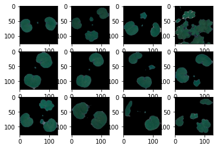

```python
new_train = []
sets = []; getEx = True
for i in x:
    blurr = cv2.GaussianBlur(i,(5,5),0)
    hsv = cv2.cvtColor(blurr,cv2.COLOR_BGR2HSV) #Using BGR TO HSV conversion.
    lower = (25,40,50)
    upper = (75,255,255)
    mask = cv2.inRange(hsv,lower,upper) # create a mask
    struc = cv2.getStructuringElement(cv2.MORPH_ELLIPSE,(11,11)) #getting structring element ( kernel) of sie 11x11
    mask = cv2.morphologyEx(mask,cv2.MORPH_CLOSE,struc) # applying morphological transformation ( closing operation ) to remove imperfections from the binary image ( mask)
    boolean = mask>0
    new = np.zeros_like(i,np.uint8)
    new[boolean] = i[boolean]
    new_train.append(new)
    if getEx:
        plt.subplot(2,3,1);plt.imshow(i) # ORIGINAL
        plt.subplot(2,3,2);plt.imshow(blurr) # BLURRED
        plt.subplot(2,3,3);plt.imshow(hsv) # HSV CONVERTED
        plt.subplot(2,3,4);plt.imshow(mask) # MASKED
        plt.subplot(2,3,5);plt.imshow(boolean) # BOOLEAN MASKED
        plt.subplot(2,3,6);plt.imshow(new) # NEW PROCESSED IMAGE
        plt.show()
        getEx = False
new_train = np.asarray(new_train)
print("# SAMPLES OF CLEANED IMAGES")
for i in range(12):
    plt.subplot(3,4,i+1)
    plt.imshow(new_train[i])
```

[output not shown]

### Normalising the Images

```python
 # normalize the training data
clearTrainImge = new_train/255
```

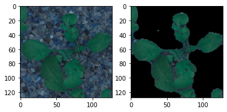

```python
plt.subplot(1, 2, 1); plt.imshow(x[1000])  # Show the original image
plt.subplot(1, 2, 2); plt.imshow(clearTrainImge[1000])#Normalized image
```

We can see from the above a sample of plant before and after the normalisation was done.

```python
# check the data type of the training images
clearTrainImge.dtype
```

```
dtype('float64')
```

```python
#to print the shape of normailised image data and the labels
images = np.array(clearTrainImge)
classes_final = np.array(y)# converting the Labels into np.array data format
print("images shape: ", images.shape)
print("classes shape: ", classes_final.shape)
```

```
images shape:  (4750, 128, 128, 3)
classes shape:  (4750, 1)
```

```python
#Let's put the 12 labels in a dataframe.
classes = ['Black-grass', 'Charlock', 'Cleavers', 'Common Chickweed',
              'Common wheat', 'Fat Hen', 'Loose Silky-bent',
              'Maize', 'Scentless Mayweed', 'Shepherds Purse',
              'Small-flowered Cranesbill', 'Sugar beet']
```

### Label Encoding

We will now encode the plants classes using LabelBinarizer so as to prepare it for model building.

```python
#To encode the labels
enc = LabelBinarizer()
y_final = enc.fit_transform(classes_final)
```

```python
y_final[0]# to check the first row of the encoded label data
```

```
array([0, 0, 0, 0, 0, 0, 0, 0, 0, 0, 1, 0])
```

```python
#To check the final shape of our data sets which we shall split and pass into our models
print("images shape: ", images.shape)
print("classes shape: ", y_final.shape)
```

```
images shape:  (4750, 128, 128, 3)
classes shape:  (4750, 12)
```

We can see now the the labels data(classes) now has 4750 rows and 12 columns after the encoding.

### Splitting the data set

We will first split the data into train and test while we will further split the test data in validation and test data.

```python
#To split the data into train and test data sets
X_train, X_test, y_train, y_test = train_test_split(images, y_final, test_size=0.3, random_state=50,stratify=y_final)
```

```python
# To further split the test data into validation and test data sets
random_seed = 2
X_test, X_val, y_test, Y_val = train_test_split(X_test,y_test, test_size = 0.5, random_state=random_seed,stratify=y_test)
```

```python
#To check the final shape of data sets after splitting
print("Train set: ", X_train.shape)
print("Validation set: ", X_val.shape)
print("Test set: ", X_test.shape)
print("Train classes: ", y_train.shape)
print("Validation classes: ", Y_val.shape)
print("Test Classes: ", y_test.shape)
```

```
Train set:  (3325, 128, 128, 3)
Validation set:  (713, 128, 128, 3)
Test set:  (712, 128, 128, 3)
Train classes:  (3325, 12)
Validation classes:  (713, 12)
Test Classes:  (712, 12)
```

## Model Building

**Model_1**

Building the first model with dropout in the convolution layer and 30 epochs.

```python
# Building the first model

batch_size = None

model = Sequential()

model.add(Conv2D(filters = 32, kernel_size = (5,5),padding = 'Same',
                 activation ='relu', batch_input_shape = (batch_size,128,128, 3)))#the input layer


model.add(Conv2D(filters = 32, kernel_size = (5,5),padding = 'Same',
                 activation ='relu'))
model.add(MaxPool2D(pool_size=(2,2)))#applying max pooling to the convolution layer
model.add(Dropout(0.2))#applying dropout to the convolution layer


model.add(Conv2D(filters = 64, kernel_size = (3,3),padding = 'Same',
                 activation ='relu'))
model.add(Conv2D(filters = 64, kernel_size = (3,3),padding = 'same',
                 activation ='relu'))
model.add(MaxPool2D(pool_size=(2,2), strides=(2,2)))
model.add(Dropout(0.3))

model.add(Conv2D(filters = 64, kernel_size = (3,3),padding = 'Same',
                 activation ='relu'))
model.add(Conv2D(filters = 64, kernel_size = (3,3),padding = 'Same',
                 activation ='relu'))
model.add(MaxPool2D(pool_size=(2,2), strides=(2,2)))
model.add(Dropout(0.4))



model.add(Flatten())#to flatten the feature map for dense layer usage
model.add(Dense(192, activation = "relu"))#the hidden layer
model.add(Dropout(0.5))#adding dropout to the hidden layer
model.add(Dense(12, activation = "softmax"))#applying softmax activation to the output layer that has 12 classes
model.summary()
```

```
Model: "sequential"
_________________________________________________________________
 Layer (type)                Output Shape              Param #
=================================================================
 conv2d (Conv2D)             (None, 128, 128, 32)      2432

 conv2d_1 (Conv2D)           (None, 128, 128, 32)      25632

 max_pooling2d (MaxPooling2D  (None, 64, 64, 32)       0
 )

 dropout (Dropout)           (None, 64, 64, 32)        0

 conv2d_2 (Conv2D)           (None, 64, 64, 64)        18496

 conv2d_3 (Conv2D)           (None, 64, 64, 64)        36928

 max_pooling2d_1 (MaxPooling  (None, 32, 32, 64)       0
 2D)

 dropout_1 (Dropout)         (None, 32, 32, 64)        0

 conv2d_4 (Conv2D)           (None, 32, 32, 64)        36928

 conv2d_5 (Conv2D)           (None, 32, 32, 64)        36928

 max_pooling2d_2 (MaxPooling  (None, 16, 16, 64)       0
 2D)

 dropout_2 (Dropout)         (None, 16, 16, 64)        0

 flatten (Flatten)           (None, 16384)             0

 dense (Dense)               (None, 192)               3145920

 dropout_3 (Dropout)         (None, 192)               0

 dense_1 (Dense)             (None, 12)                2316

=================================================================
Total params: 3,305,580
Trainable params: 3,305,580
Non-trainable params: 0
_________________________________________________________________
```

```python
#Setting other model parameters
opt = Adam(learning_rate=0.001)
optimizer = RMSprop(learning_rate=0.001, rho=0.9, epsilon=1e-08, decay=0.0)
model.compile(optimizer = optimizer, loss = "categorical_crossentropy", metrics = ["accuracy"]) #compiling the first model
```

```python
model_1=model.fit(X_train, y_train, epochs = 30, validation_data = (X_val,Y_val),batch_size = batch_size)
```

[output not shown]

The Model gives accuracy of 0.94 and 0.75 on train and validation set respectively. This shows that the model overfits the train set. We shall therefore build other models to check for improved performance.

Model 2: CNN with Dropout after Convolution and having two Dense layers with 32 & 24 units respectively

Since CNN Model 1 does not appear to have good validation accuracy and appears to be overfitting on the training dataset, let's use CNN Model 2, which has a different architecture and see whether that will generalize well and not overfit.

```python
#Setting the structure for model_2
class conv_Layers:

  def __init__(self, nfilters, kernel_size, stride=1,
               pool_size=2, leakyrelu_slope=0.1, dropc=0.0, bnorm=False):
    self.nfilters = nfilters
    self.kernel_size = kernel_size
    self.stride = stride
    self.pool_size = pool_size
    self.leakyrelu_slope = leakyrelu_slope
    self.dropfrac = dropc
    self.bnorm = bnorm

  def __call__(self, x):
    x = Conv2D(self.nfilters, kernel_size=self.kernel_size,
               strides=self.stride, padding='same')(x)
    x = LeakyReLU(self.leakyrelu_slope)(x)
    if (self.dropfrac > 0.0):
      x = Dropout(self.dropfrac)(x)
    if (self.bnorm):
      x = BatchNormalization()(x)
    x = MaxPool2D(self.pool_size)(x)
    return x

class dense_Layers:

  def __init__(self, nunits, leakyrelu_slope=0.1, dropd=0.0, bnorm=False):
    self.nunits = nunits
    self.leakyrelu_slope = leakyrelu_slope
    self.dropfrac = dropd
    self.bnorm = bnorm

  def __call__(self, x):
    x = Dense(self.nunits)(x)
    x = LeakyReLU(self.leakyrelu_slope)(x)
    if (self.dropfrac > 0.0):
      x = Dropout(self.dropfrac)(x)
    if (self.bnorm):
      x = BatchNormalization()(x)
    return x

def LNmodel(in_shape, conv_filters, dense_filters, kernel_size, num_classes, lr,
            stride=1, pool_size=2, leakyrelu_slope=0.1, dropc=0.0, dropd=0.0, bnorm=False):

  in_shape = X_train.shape[1:]
  i = Input(shape=in_shape)
  for ncl, nconvfilters in enumerate(conv_filters):
    if (ncl==0):
      x = conv_Layers(nconvfilters, kernel_size,
                      stride, pool_size, leakyrelu_slope, dropc, bnorm)(i)
    else:
      x = conv_Layers(nconvfilters, kernel_size,
                      stride, pool_size, leakyrelu_slope, dropc, bnorm)(x)

  x = Flatten()(x)

  for ndl, ndunits in enumerate(dense_filters):
    x = dense_Layers(ndunits, leakyrelu_slope, dropd, bnorm)(x)

  x = Dense(num_classes, activation='softmax')(x)

  ln_model  = Model(inputs=i, outputs=x)
  adam = optimizers.Adam(lr=lr)
  ln_model.compile(loss='categorical_crossentropy', optimizer=adam, metrics=['accuracy'])
  return ln_model
```

```python
lr = 0.001
kernelsize = 5
in_shape= X_train.shape[1:]
model_2 = LNmodel(in_shape, [24,32], [32,24], kernelsize, 12, lr,
                    stride=1, pool_size=2, leakyrelu_slope=0.1, dropc=0.25,
                    dropd=0.5, bnorm=False)
model_2.summary()
```

```
Model: "model"
_________________________________________________________________
 Layer (type)                Output Shape              Param #
=================================================================
 input_1 (InputLayer)        [(None, 128, 128, 3)]     0

 conv2d_6 (Conv2D)           (None, 128, 128, 24)      1824

 leaky_re_lu (LeakyReLU)     (None, 128, 128, 24)      0

 dropout_4 (Dropout)         (None, 128, 128, 24)      0

 max_pooling2d_3 (MaxPooling  (None, 64, 64, 24)       0
 2D)

 conv2d_7 (Conv2D)           (None, 64, 64, 32)        19232

 leaky_re_lu_1 (LeakyReLU)   (None, 64, 64, 32)        0

 dropout_5 (Dropout)         (None, 64, 64, 32)        0

 max_pooling2d_4 (MaxPooling  (None, 32, 32, 32)       0
 2D)

 flatten_1 (Flatten)         (None, 32768)             0

 dense_2 (Dense)             (None, 32)                1048608

 leaky_re_lu_2 (LeakyReLU)   (None, 32)                0

 dropout_6 (Dropout)         (None, 32)                0

 dense_3 (Dense)             (None, 24)                792

 leaky_re_lu_3 (LeakyReLU)   (None, 24)                0

 dropout_7 (Dropout)         (None, 24)                0

 dense_4 (Dense)             (None, 12)                300

=================================================================
Total params: 1,070,756
Trainable params: 1,070,756
Non-trainable params: 0
_________________________________________________________________
```

```python
es = EarlyStopping(monitor='val_loss', mode='min', verbose=1, patience=5)#Applying earlystopping to the model
mc = ModelCheckpoint('best_model.h5', monitor='val_accuracy', mode='max', verbose=1, save_best_only=True)#to allow model saving at checkpoints

history_model_2 = model_2.fit(X_train, y_train,
                                  validation_data=(X_val,Y_val),
                                  verbose=1, batch_size=256,
                                  shuffle=True, epochs=50,callbacks=[es,mc])#to fit the Model_2
```

```
Epoch 1: val_accuracy improved from -inf to 0.25105, saving model to best_model.h5
Epoch 2: val_accuracy improved from 0.25105 to 0.32398, saving model to best_model.h5
Epoch 3: val_accuracy did not improve from 0.32398
Epoch 4: val_accuracy improved from 0.32398 to 0.37027, saving model to best_model.h5
Epoch 5: val_accuracy improved from 0.37027 to 0.48808, saving model to best_model.h5
Epoch 6: val_accuracy improved from 0.48808 to 0.50351, saving model to best_model.h5
Epoch 7: val_accuracy improved from 0.50351 to 0.52875, saving model to best_model.h5
Epoch 8: val_accuracy improved from 0.52875 to 0.59748, saving model to best_model.h5
Epoch 9: val_accuracy did not improve from 0.59748
Epoch 10: val_accuracy improved from 0.59748 to 0.61992, saving model to best_model.h5
Epoch 11: val_accuracy improved from 0.61992 to 0.62973, saving model to best_model.h5
Epoch 12: val_accuracy improved from 0.62973 to 0.64797, saving model to best_model.h5
Epoch 13: val_accuracy did not improve from 0.64797
Epoch 14: val_accuracy improved from 0.64797 to 0.66199, saving model to best_model.h5
Epoch 15: val_accuracy did not improve from 0.66199
Epoch 16: val_accuracy did not improve from 0.66199
Epoch 17: val_accuracy did not improve from 0.66199
Epoch 18: val_accuracy did not improve from 0.66199
Epoch 19: val_accuracy did not improve from 0.66199
Epoch 20: val_accuracy improved from 0.66199 to 0.66480, saving model to best_model.h5
Epoch 21: val_accuracy did not improve from 0.66480
Epoch 22: val_accuracy did not improve from 0.66480
Epoch 23: val_accuracy did not improve from 0.66480
Epoch 24: val_accuracy improved from 0.66480 to 0.66760, saving model to best_model.h5
Epoch 25: val_accuracy improved from 0.66760 to 0.67742, saving model to best_model.h5
Epoch 26: val_accuracy improved from 0.67742 to 0.68303, saving model to best_model.h5
Epoch 27: val_accuracy did not improve from 0.68303
Epoch 28: val_accuracy did not improve from 0.68303
Epoch 29: val_accuracy improved from 0.68303 to 0.69004, saving model to best_model.h5
Epoch 30: val_accuracy did not improve from 0.69004
Epoch 31: val_accuracy did not improve from 0.69004
Epoch 31: early stopping
```

This Model_2 unfortunately **does not have a better validation accuracy,** with accuracy 0f 0.67 and it still **overfit the training dataset.** That means we need to increase the complexity of the model in our next attempt.

Convolutional Neural Network (CNN) Model 3: CNN with Dropout after Convolution and having two Dense layers with 192 & 256 Units respectively

```python
learning_rate = 0.001
kernelsize = 5
model_3 = LNmodel(in_shape, [8,16], [192,256], kernelsize, 12, learning_rate,
                    stride=1, pool_size=2, leakyrelu_slope=0.1, dropc=0.25,
                    dropd=0.5, bnorm=False)
model_3.summary()
```

```
Model: "model_1"
_________________________________________________________________
 Layer (type)                Output Shape              Param #
=================================================================
 input_2 (InputLayer)        [(None, 128, 128, 3)]     0

 conv2d_8 (Conv2D)           (None, 128, 128, 8)       608

 leaky_re_lu_4 (LeakyReLU)   (None, 128, 128, 8)       0

 dropout_8 (Dropout)         (None, 128, 128, 8)       0

 max_pooling2d_5 (MaxPooling  (None, 64, 64, 8)        0
 2D)

 conv2d_9 (Conv2D)           (None, 64, 64, 16)        3216

 leaky_re_lu_5 (LeakyReLU)   (None, 64, 64, 16)        0

 dropout_9 (Dropout)         (None, 64, 64, 16)        0

 max_pooling2d_6 (MaxPooling  (None, 32, 32, 16)       0
 2D)

 flatten_2 (Flatten)         (None, 16384)             0

 dense_5 (Dense)             (None, 192)               3145920

 leaky_re_lu_6 (LeakyReLU)   (None, 192)               0

 dropout_10 (Dropout)        (None, 192)               0

 dense_6 (Dense)             (None, 256)               49408

 leaky_re_lu_7 (LeakyReLU)   (None, 256)               0

 dropout_11 (Dropout)        (None, 256)               0

 dense_7 (Dense)             (None, 12)                3084

=================================================================
Total params: 3,202,236
Trainable params: 3,202,236
Non-trainable params: 0
_________________________________________________________________
```

```python
#Applying earlystopping and modelcheckpoint to the model as well
es = EarlyStopping(monitor='val_loss', mode='min', verbose=1, patience=20)
mc = ModelCheckpoint('best_model.h5', monitor='val_accuracy', mode='max', verbose=1, save_best_only=True)

history_model_3 = model_3.fit(X_train, y_train,
                                  validation_data=(X_val,Y_val),
                                  verbose=1, batch_size=512,
                                  shuffle=True, epochs=50,callbacks=[es,mc])
```

```
Epoch 1: val_accuracy improved from -inf to 0.31136, saving model to best_model.h5
Epoch 2: val_accuracy improved from 0.31136 to 0.40813, saving model to best_model.h5
Epoch 3: val_accuracy improved from 0.40813 to 0.46003, saving model to best_model.h5
Epoch 4: val_accuracy improved from 0.46003 to 0.53997, saving model to best_model.h5
Epoch 5: val_accuracy improved from 0.53997 to 0.58906, saving model to best_model.h5
Epoch 6: val_accuracy improved from 0.58906 to 0.62553, saving model to best_model.h5
Epoch 7: val_accuracy improved from 0.62553 to 0.62833, saving model to best_model.h5
Epoch 8: val_accuracy improved from 0.62833 to 0.65217, saving model to best_model.h5
Epoch 9: val_accuracy improved from 0.65217 to 0.65498, saving model to best_model.h5
Epoch 10: val_accuracy improved from 0.65498 to 0.70687, saving model to best_model.h5
Epoch 11: val_accuracy improved from 0.70687 to 0.72370, saving model to best_model.h5
Epoch 12: val_accuracy did not improve from 0.72370
Epoch 13: val_accuracy did not improve from 0.72370
Epoch 14: val_accuracy improved from 0.72370 to 0.73633, saving model to best_model.h5
Epoch 15: val_accuracy improved from 0.73633 to 0.75035, saving model to best_model.h5
Epoch 16: val_accuracy did not improve from 0.75035
Epoch 17: val_accuracy did not improve from 0.75035
Epoch 18: val_accuracy did not improve from 0.75035
Epoch 19: val_accuracy did not improve from 0.75035
Epoch 20: val_accuracy did not improve from 0.75035
Epoch 21: val_accuracy did not improve from 0.75035
Epoch 22: val_accuracy did not improve from 0.75035
Epoch 23: val_accuracy did not improve from 0.75035
Epoch 24: val_accuracy did not improve from 0.75035
Epoch 25: val_accuracy did not improve from 0.75035
Epoch 26: val_accuracy did not improve from 0.75035
Epoch 27: val_accuracy did not improve from 0.75035
Epoch 28: val_accuracy did not improve from 0.75035
Epoch 29: val_accuracy did not improve from 0.75035
Epoch 30: val_accuracy did not improve from 0.75035
Epoch 31: val_accuracy did not improve from 0.75035
Epoch 32: val_accuracy did not improve from 0.75035
Epoch 33: val_accuracy did not improve from 0.75035
Epoch 34: val_accuracy did not improve from 0.75035
Epoch 35: val_accuracy did not improve from 0.75035
Epoch 36: val_accuracy did not improve from 0.75035
Epoch 37: val_accuracy did not improve from 0.75035
Epoch 37: early stopping
```

Model_3 shows best performance so far on the train set with accuracy of 0.98 but shows not too good performance on the validation set 0.73. This is a very overfitting model as well

**Plotting the Train & Validation Accuracy**

**CNN Model 1**

```
dict_keys(['loss', 'accuracy', 'val_loss', 'val_accuracy'])
```

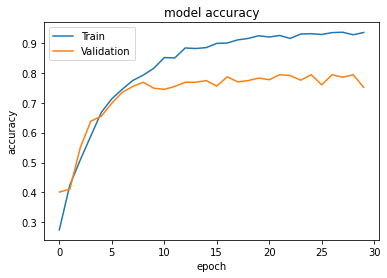

```python
#Plotting the accuracy curve for Model_1
print(model_1.history.keys())
# summarize history for accuracy
plt.plot(model_1.history['accuracy'])
plt.plot(model_1.history['val_accuracy'])
plt.title('model accuracy')
plt.ylabel('accuracy')
plt.xlabel('epoch')
plt.legend(['Train', 'Validation'], loc='upper left')
plt.show()
```

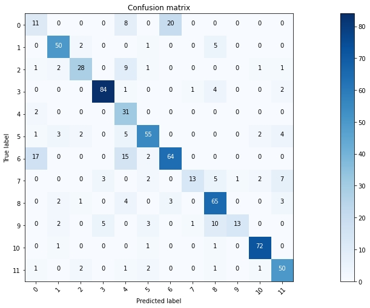

```python
#Plotting the confusion matrix of Model_1
plt.subplots(figsize=(22,7)) #set the size of the plot

def plot_confusion_matrix(cm, classes,
                          normalize=False,
                          title='Confusion matrix',
                          cmap=plt.cm.Blues):
    """
    This function prints and plots the confusion matrix.
    Normalization can be applied by setting `normalize=True`.
    """
    plt.imshow(cm, interpolation='nearest', cmap=cmap)
    plt.title(title)
    plt.colorbar()
    tick_marks = range(len(classes))
    plt.xticks(tick_marks, classes, rotation=45)
    plt.yticks(tick_marks, classes)

    if normalize:
        cm = cm.astype('float') / cm.sum(axis=1)[:, np.newaxis]

    thresh = cm.max() / 2.
    for i, j in itertools.product(range(cm.shape[0]), range(cm.shape[1])):
        plt.text(j, i, cm[i, j],
                 horizontalalignment="center",
                 color="white" if cm[i, j] > thresh else "black")

    plt.tight_layout()
    plt.ylabel('True label')
    plt.xlabel('Predicted label')

# Predict the values from the validation dataset
Y_pred = model.predict(X_val)
# Convert predictions classes to one hot vectors
Y_pred_classes = np.argmax(Y_pred,axis = 1)
# Convert validation observations to one hot vectors
Y_true = np.argmax(Y_val,axis = 1)
# compute the confusion matrix
confusion_mtx = confusion_matrix(Y_true, Y_pred_classes)
# plot the confusion matrix
plot_confusion_matrix(confusion_mtx, classes = range(len(classes)))
```

```python
#Let' print the plant specie each label on the confusion matrix represents.
print('0 represents:', classes[0])
print('1 represents:', classes[1])
print('2 represents:', classes[2])
print('3 represents:', classes[3])
print('4 represents:', classes[4])
print('5 represents:', classes[5])
print('6 represents:', classes[6])
print('7 represents:', classes[7])
print('8 represents:', classes[8])
print('9 represents:', classes[9])
print('10 represents:', classes[10])
print('11 represents:', classes[11])
```

```
0 represents: Black-grass
1 represents: Charlock
2 represents: Cleavers
3 represents: Common Chickweed
4 represents: Common wheat
5 represents: Fat Hen
6 represents: Loose Silky-bent
7 represents: Maize
8 represents: Scentless Mayweed
9 represents: Shepherds Purse
10 represents: Small-flowered Cranesbill
11 represents: Sugar beet
```

From the confusion matrix above, it is clear that the Black-grass is the highest misclassified plant specie by Model 1. It is often confused to Loose Silky-bent and vice versa. The model only correctly identifies 11 out of 39 Black-grass in the validation dataset.

**CNN Model 2**

```
dict_keys(['loss', 'accuracy', 'val_loss', 'val_accuracy'])
```

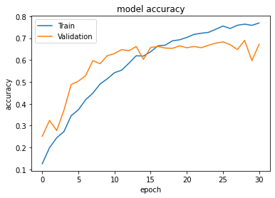

```python
#Plotting the accuracy curve for Model_2
print(history_model_2.history.keys())
# summarize history for accuracy
plt.plot(history_model_2.history['accuracy'])
plt.plot(history_model_2.history['val_accuracy'])
plt.title('model accuracy')
plt.ylabel('accuracy')
plt.xlabel('epoch')
plt.legend(['Train', 'Validation'], loc='upper left')
plt.show()
```

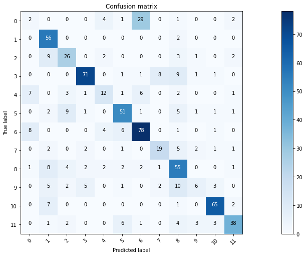

```python
#Plotting the confusion matrix of Model_2
plt.subplots(figsize=(22,7)) #set the size of the plot

def plot_confusion_matrix(cm, classes,
                          normalize=False,
                          title='Confusion matrix',
                          cmap=plt.cm.Blues):
    """
    This function prints and plots the confusion matrix.
    Normalization can be applied by setting `normalize=True`.
    """
    plt.imshow(cm, interpolation='nearest', cmap=cmap)
    plt.title(title)
    plt.colorbar()
    tick_marks = np.arange(len(classes))
    plt.xticks(tick_marks, classes, rotation=45)
    plt.yticks(tick_marks, classes)

    if normalize:
        cm = cm.astype('float') / cm.sum(axis=1)[:, np.newaxis]

    thresh = cm.max() / 2.
    for i, j in itertools.product(range(cm.shape[0]), range(cm.shape[1])):
        plt.text(j, i, cm[i, j],
                 horizontalalignment="center",
                 color="white" if cm[i, j] > thresh else "black")

    plt.tight_layout()
    plt.ylabel('True label')
    plt.xlabel('Predicted label')

# Predict the values from the validation dataset
Y_pred = model_2.predict(X_val)
# Convert predictions classes to one hot vectors
Y_pred_classes = np.argmax(Y_pred,axis = 1)
# Convert validation observations to one hot vectors
Y_true = np.argmax(Y_val,axis = 1)
# compute the confusion matrix
confusion_mtx = confusion_matrix(Y_true, Y_pred_classes)
# plot the confusion matrix
plot_confusion_matrix(confusion_mtx, classes = range(12))
```

The Model 2 confusion matrix above shows that the plant misclassification is still high. The model still performs poorly in identifying sustantial number of Black-grass,Common Chickweed, Common wheat,Loose Silky Grass, among others.

**CNN Model 3**

```
dict_keys(['loss', 'accuracy', 'val_loss', 'val_accuracy'])
```

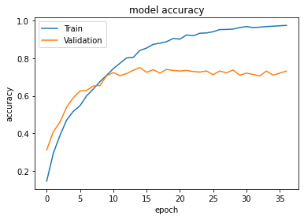

```python
#Plotting the accuracy curve for Model_3
print(history_model_3.history.keys())
# summarize history for accuracy
plt.plot(history_model_3.history['accuracy'])
plt.plot(history_model_3.history['val_accuracy'])
plt.title('model accuracy')
plt.ylabel('accuracy')
plt.xlabel('epoch')
plt.legend(['Train', 'Validation'], loc='upper left')
plt.show()
```

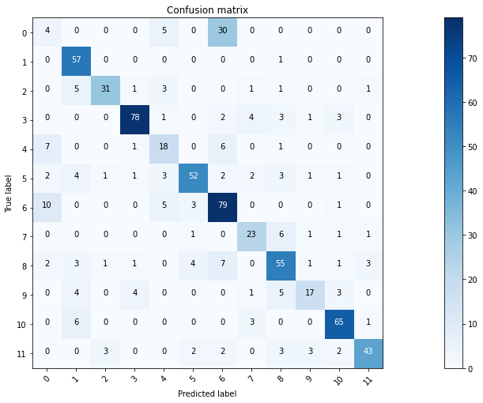

```python
#Plotting the confusion matrix of Model_3
plt.subplots(figsize=(22,7)) #set the size of the plot

def plot_confusion_matrix(cm, classes,
                          normalize=False,
                          title='Confusion matrix',
                          cmap=plt.cm.Blues):
    """
    This function prints and plots the confusion matrix.
    Normalization can be applied by setting `normalize=True`.
    """
    plt.imshow(cm, interpolation='nearest', cmap=cmap)
    plt.title(title)
    plt.colorbar()
    tick_marks = np.arange(len(classes))
    plt.xticks(tick_marks, classes, rotation=45)
    plt.yticks(tick_marks, classes)

    if normalize:
        cm = cm.astype('float') / cm.sum(axis=1)[:, np.newaxis]

    thresh = cm.max() / 2.
    for i, j in itertools.product(range(cm.shape[0]), range(cm.shape[1])):
        plt.text(j, i, cm[i, j],
                 horizontalalignment="center",
                 color="white" if cm[i, j] > thresh else "black")

    plt.tight_layout()
    plt.ylabel('True label')
    plt.xlabel('Predicted label')

# Predict the values from the validation dataset
Y_pred = model_3.predict(X_val)
# Convert predictions classes to one hot vectors
Y_pred_classes = np.argmax(Y_pred,axis = 1)
# Convert validation observations to one hot vectors
Y_true = np.argmax(Y_val,axis = 1)
# compute the confusion matrix
confusion_mtx = confusion_matrix(Y_true, Y_pred_classes)
# plot the confusion matrix
plot_confusion_matrix(confusion_mtx, classes = range(12))
```

The confusion matrix above shows that the plant misclassification is still high. The model still performs poorly in identifying sustantial number of Black-grass,Common wheat,Loose Silky-bent,Maize, and Sheperds Purse among others.

**Data Augmentation**

Since the data is an imbalanced data as earlier highlighted, we will therefore explore data augmentation and build another model for possible improved performance. Although this will not address the imbalance in the data but is expected to help reduce the overfitting seen in the earlier 3 models built.

```python
#to augment the data through rotation,zooming,shifting,and fliping
datagen = ImageDataGenerator(
        rotation_range=180,  # randomly rotate images in the range
        zoom_range = 0.1, # Randomly zoom image
        width_shift_range=0.1,  # randomly shift images horizontally
        height_shift_range=0.1,  # randomly shift images vertically
        horizontal_flip=True,  # randomly flip images horizontally
        vertical_flip=True  # randomly flip images vertically
    )
datagen.fit(X_train)
```

```python
#building the Model_4 achitecture
seed = seed
model = Sequential()
model.add(layers.Conv2D(32, (3, 3), activation='relu', input_shape=(128, 128, 3)))
model.add(layers.MaxPooling2D((2, 2))) # to downsample the feature maps
model.add(layers.Conv2D(64, (3, 3), activation='relu'))
model.add(layers.MaxPooling2D((2, 2)))
model.add(layers.Conv2D(128, (3, 3), activation='relu'))
model.add(layers.MaxPooling2D((2, 2)))
model.add(layers.Conv2D(128, (3, 3), activation='relu'))
model.add(layers.MaxPooling2D((2, 2)))
model.add(layers.Flatten())
model.add(layers.Dense(64, activation='relu'))
model.add(layers.Dense(12, activation='softmax'))
model.compile(loss='categorical_crossentropy', optimizer='adam', metrics=['accuracy'])

model_4 = model
model_4.summary()
```

```
Model: "sequential_1"
_________________________________________________________________
 Layer (type)                Output Shape              Param #
=================================================================
 conv2d_10 (Conv2D)          (None, 126, 126, 32)      896

 max_pooling2d_7 (MaxPooling  (None, 63, 63, 32)       0
 2D)

 conv2d_11 (Conv2D)          (None, 61, 61, 64)        18496

 max_pooling2d_8 (MaxPooling  (None, 30, 30, 64)       0
 2D)

 conv2d_12 (Conv2D)          (None, 28, 28, 128)       73856

 max_pooling2d_9 (MaxPooling  (None, 14, 14, 128)      0
 2D)

 conv2d_13 (Conv2D)          (None, 12, 12, 128)       147584

 max_pooling2d_10 (MaxPoolin  (None, 6, 6, 128)        0
 g2D)

 flatten_3 (Flatten)         (None, 4608)              0

 dense_8 (Dense)             (None, 64)                294976

 dense_9 (Dense)             (None, 12)                780

=================================================================
Total params: 536,588
Trainable params: 536,588
Non-trainable params: 0
_________________________________________________________________
```

```python
#fitting the model on the train set
history_A = model_4.fit_generator(datagen.flow(X_train, y_train, batch_size=75), epochs=35, validation_data=(X_val, Y_val), verbose=2)
```

```
45/45 - 13s - loss: 2.1305 - accuracy: 0.2812 - val_loss: 1.8578 - val_accuracy: 0.4039 - 13s/epoch - 285ms/step
45/45 - 11s - loss: 1.7371 - accuracy: 0.3844 - val_loss: 1.7250 - val_accuracy: 0.3871 - 11s/epoch - 248ms/step
45/45 - 11s - loss: 1.5154 - accuracy: 0.4665 - val_loss: 1.2826 - val_accuracy: 0.5750 - 11s/epoch - 248ms/step
45/45 - 11s - loss: 1.1755 - accuracy: 0.5985 - val_loss: 0.9376 - val_accuracy: 0.6985 - 11s/epoch - 248ms/step
45/45 - 11s - loss: 1.0496 - accuracy: 0.6493 - val_loss: 0.8641 - val_accuracy: 0.7041 - 11s/epoch - 248ms/step
45/45 - 11s - loss: 0.9563 - accuracy: 0.6812 - val_loss: 0.8026 - val_accuracy: 0.7391 - 11s/epoch - 249ms/step
45/45 - 11s - loss: 0.8352 - accuracy: 0.7215 - val_loss: 0.6583 - val_accuracy: 0.7714 - 11s/epoch - 249ms/step
45/45 - 11s - loss: 0.7841 - accuracy: 0.7465 - val_loss: 0.6206 - val_accuracy: 0.7840 - 11s/epoch - 250ms/step
45/45 - 11s - loss: 0.7370 - accuracy: 0.7552 - val_loss: 0.6328 - val_accuracy: 0.7896 - 11s/epoch - 249ms/step
45/45 - 11s - loss: 0.7379 - accuracy: 0.7585 - val_loss: 0.5927 - val_accuracy: 0.8050 - 11s/epoch - 249ms/step
45/45 - 11s - loss: 0.7048 - accuracy: 0.7654 - val_loss: 0.6564 - val_accuracy: 0.7798 - 11s/epoch - 250ms/step
45/45 - 11s - loss: 0.6546 - accuracy: 0.7871 - val_loss: 0.5624 - val_accuracy: 0.8177 - 11s/epoch - 251ms/step
45/45 - 11s - loss: 0.6260 - accuracy: 0.7922 - val_loss: 0.5875 - val_accuracy: 0.7882 - 11s/epoch - 251ms/step
45/45 - 11s - loss: 0.6181 - accuracy: 0.7979 - val_loss: 0.5049 - val_accuracy: 0.8303 - 11s/epoch - 249ms/step
45/45 - 11s - loss: 0.5713 - accuracy: 0.8030 - val_loss: 0.4849 - val_accuracy: 0.8345 - 11s/epoch - 250ms/step
45/45 - 11s - loss: 0.5922 - accuracy: 0.7985 - val_loss: 0.5391 - val_accuracy: 0.8233 - 11s/epoch - 249ms/step
45/45 - 11s - loss: 0.5473 - accuracy: 0.8138 - val_loss: 0.4473 - val_accuracy: 0.8499 - 11s/epoch - 249ms/step
45/45 - 11s - loss: 0.5311 - accuracy: 0.8162 - val_loss: 0.4538 - val_accuracy: 0.8443 - 11s/epoch - 249ms/step
45/45 - 11s - loss: 0.5058 - accuracy: 0.8280 - val_loss: 0.4694 - val_accuracy: 0.8429 - 11s/epoch - 248ms/step
45/45 - 11s - loss: 0.4836 - accuracy: 0.8343 - val_loss: 0.4715 - val_accuracy: 0.8457 - 11s/epoch - 250ms/step
45/45 - 11s - loss: 0.4768 - accuracy: 0.8352 - val_loss: 0.4794 - val_accuracy: 0.8415 - 11s/epoch - 251ms/step
45/45 - 11s - loss: 0.4633 - accuracy: 0.8388 - val_loss: 0.4964 - val_accuracy: 0.8401 - 11s/epoch - 250ms/step
45/45 - 11s - loss: 0.4474 - accuracy: 0.8397 - val_loss: 0.4674 - val_accuracy: 0.8401 - 11s/epoch - 250ms/step
45/45 - 11s - loss: 0.4650 - accuracy: 0.8307 - val_loss: 0.3583 - val_accuracy: 0.8682 - 11s/epoch - 250ms/step
45/45 - 11s - loss: 0.4104 - accuracy: 0.8460 - val_loss: 0.3658 - val_accuracy: 0.8752 - 11s/epoch - 248ms/step
45/45 - 11s - loss: 0.4114 - accuracy: 0.8556 - val_loss: 0.3793 - val_accuracy: 0.8696 - 11s/epoch - 249ms/step
45/45 - 11s - loss: 0.3740 - accuracy: 0.8595 - val_loss: 0.3647 - val_accuracy: 0.8612 - 11s/epoch - 250ms/step
45/45 - 11s - loss: 0.4116 - accuracy: 0.8565 - val_loss: 0.3929 - val_accuracy: 0.8569 - 11s/epoch - 249ms/step
45/45 - 11s - loss: 0.3698 - accuracy: 0.8674 - val_loss: 0.3567 - val_accuracy: 0.8724 - 11s/epoch - 249ms/step
45/45 - 11s - loss: 0.3686 - accuracy: 0.8632 - val_loss: 0.3306 - val_accuracy: 0.8766 - 11s/epoch - 248ms/step
45/45 - 11s - loss: 0.3574 - accuracy: 0.8722 - val_loss: 0.3162 - val_accuracy: 0.8934 - 11s/epoch - 249ms/step
45/45 - 11s - loss: 0.3896 - accuracy: 0.8559 - val_loss: 0.3680 - val_accuracy: 0.8654 - 11s/epoch - 248ms/step
45/45 - 11s - loss: 0.3351 - accuracy: 0.8746 - val_loss: 0.3345 - val_accuracy: 0.8780 - 11s/epoch - 247ms/step
45/45 - 11s - loss: 0.3366 - accuracy: 0.8770 - val_loss: 0.2715 - val_accuracy: 0.8962 - 11s/epoch - 249ms/step
45/45 - 11s - loss: 0.3231 - accuracy: 0.8809 - val_loss: 0.3210 - val_accuracy: 0.8864 - 11s/epoch - 248ms/step
```

```python
# Final evaluation of the model
scores = model_4.evaluate(X_val, Y_val, verbose=0)
scores
```

```
[0.32100415229797363, 0.8863955140113831]
```

Model_4 built on augmented data shows the best performance so far with a train and validation accuracy of 0.88 and 0.89 respectively. This shows that the model generalises well.

```
dict_keys(['loss', 'accuracy', 'val_loss', 'val_accuracy'])
```

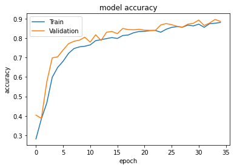

```python
#Plotting the accuracy curve for Model_4
print(history_A.history.keys())
# summarize history for accuracy
plt.plot(history_A.history['accuracy'])
plt.plot(history_A.history['val_accuracy'])
plt.title('model accuracy')
plt.ylabel('accuracy')
plt.xlabel('epoch')
plt.legend(['Train', 'Validation'], loc='upper left')
plt.show()
```

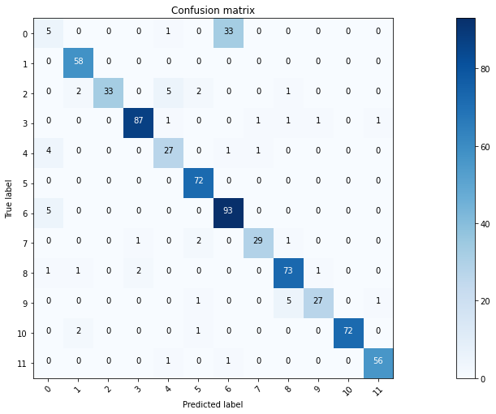

```python
#Plotting the confusion matrix of Model_4
plt.subplots(figsize=(22,7)) #set the size of the plot

def plot_confusion_matrix(cm, classes,
                          normalize=False,
                          title='Confusion matrix',
                          cmap=plt.cm.Blues):
    """
    This function prints and plots the confusion matrix.
    Normalization can be applied by setting `normalize=True`.
    """
    plt.imshow(cm, interpolation='nearest', cmap=cmap)
    plt.title(title)
    plt.colorbar()
    tick_marks = np.arange(len(classes))
    plt.xticks(tick_marks, classes, rotation=45)
    plt.yticks(tick_marks, classes)

    if normalize:
        cm = cm.astype('float') / cm.sum(axis=1)[:, np.newaxis]

    thresh = cm.max() / 2.
    for i, j in itertools.product(range(cm.shape[0]), range(cm.shape[1])):
        plt.text(j, i, cm[i, j],
                 horizontalalignment="center",
                 color="white" if cm[i, j] > thresh else "black")

    plt.tight_layout()
    plt.ylabel('True label')
    plt.xlabel('Predicted label')

# Predict the values from the validation dataset
Y_pred = model_4.predict(X_val)
# Convert predictions classes to one hot vectors
Y_pred_classes = np.argmax(Y_pred,axis = 1)
# Convert validation observations to one hot vectors
Y_true = np.argmax(Y_val,axis = 1)
# compute the confusion matrix
confusion_mtx = confusion_matrix(Y_true, Y_pred_classes)
# plot the confusion matrix
plot_confusion_matrix(confusion_mtx, classes = range(12))
```

The confusion matrix shows that the plant misclassification is at the lowest with this model.The model was able to classify correctly all Charlock and Fat Hen. However, the misclassification between Black-grass and Loose Silky-bent still persists in this model.

### **Model Evaluation**

As we can see, Model 1, 2 and Model 3 seem not to be generalizing well because they all overfit and do not have a good holdout set of Accuracy. Let us therefore check the performance of Model_4 on our test set as the model gives the highest accuracy so far.

```python
# Test Prediction
y_test_pred = model_4.predict(X_test)
y_test_pred_classes = np.argmax(y_test_pred, axis=1)
y_test_pred_prob = np.max(y_test_pred, axis=1)
```

```python
# Test Accuracy
score = model_4.evaluate(X_test, y_test, verbose=0, batch_size = 38)
print('Test loss:', score[0])
print('Test accuracy:', score[1])
```

```
Test loss: 0.31478095054626465
Test accuracy: 0.8693820238113403
```

Model_4 shows accuracy of 0.87 on the test set as well. This is still very similar to the performance of the model on the train and validation set

## **Conclusion**

Model_4 which is built on augmented data shows the best accuracy, generalises well and has the least misclassified plants as shown in the confusion matrix. We are therefore going with this model. However, all the models built struggle to identify Black-grass as it is often wrongly classified as Loose Silky-bent. There is therefore still scope for improvement in the test accuracy of the CNN model chosen here.